# Dublin Data Science Workshop on Bootstrap Methods

## 1.5 Cauchy Distribution

The cauchy distribution is unusual in that neither its mean nor its variance is defined, so we want to see how it works when we try to bootstrap sample values.

```r
F_cauchy_tbl <- tibble(x = rcauchy(10000, location = 0, scale = 1))

F_cauchy_tbl %>% glimpse()
```

```
## Observations: 10,000
## Variables: 1
## $ x <dbl> -2.0662754, -6.2379385, 0.0434845, 0.1084257, -4.4389159, -8.3486...
```

### 1.5.1 Sample Size $N=100$

```r
boot_cauchy_100_mean_tbl <- F_cauchy_tbl %>%
  head(100) %>%
  pull(x) %>%
  construct_bootstrap_size_plots(mean)

boot_cauchy_100_mean_tbl %>%
  group_by(btstrp_size) %>%
  summarise(summ = list(summary(btstrp_val))) %>%
  unnest_wider(summ)
```

```
## # A tibble: 4 x 7
##   btstrp_size  Min. `1st Qu.` Median   Mean `3rd Qu.`  Max.
##         <dbl> <dbl>     <dbl>  <dbl>  <dbl>     <dbl> <dbl>
## 1         100 -1.39    -0.467 -0.196 -0.266  -0.0426  0.507
## 2         500 -1.41    -0.482 -0.215 -0.268  -0.00404 0.658
## 3        1000 -1.83    -0.486 -0.239 -0.270  -0.0196  0.658
## 4       10000 -1.87    -0.494 -0.245 -0.268  -0.0147  1.15
```

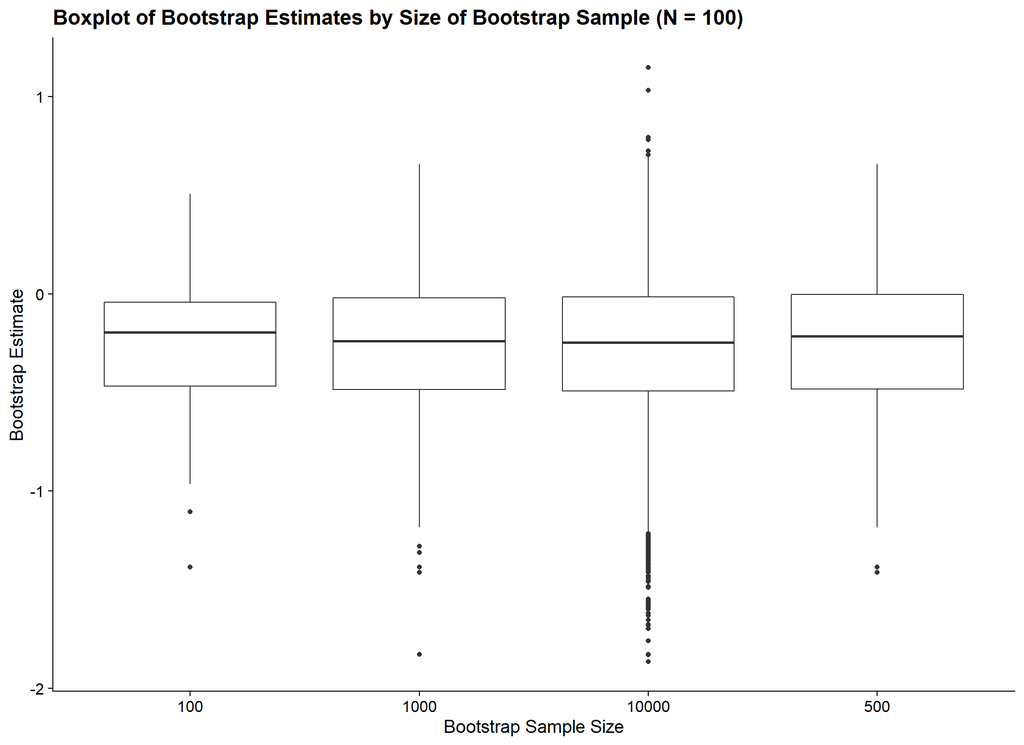

```r
ggplot(boot_cauchy_100_mean_tbl) +
  geom_boxplot(aes(x = vec_cast(btstrp_size, character()), y = btstrp_val)) +
  xlab("Bootstrap Sample Size") +
  ylab("Bootstrap Estimate") +
  ggtitle("Boxplot of Bootstrap Estimates by Size of Bootstrap Sample (N = 100)")
```

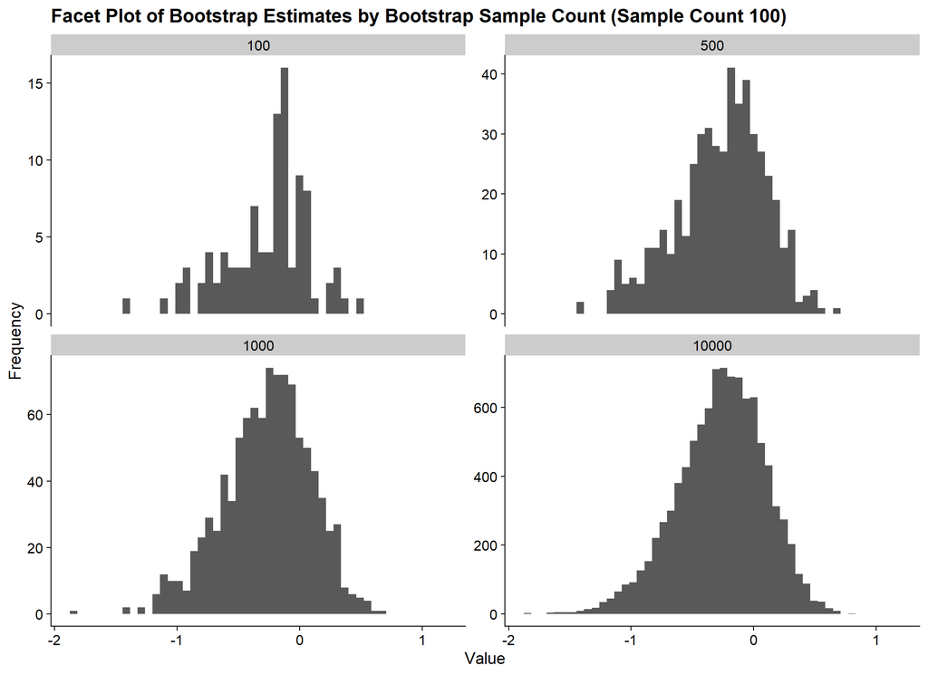

```r
ggplot(boot_cauchy_100_mean_tbl) +
  geom_histogram(aes(x = btstrp_val), bins = 50) +
  facet_wrap(vars(btstrp_size), scales = 'free_y') +
  xlab("Value") +
  ylab("Frequency") +
  ggtitle("Facet Plot of Bootstrap Estimates by Bootstrap Sample Count (Sample Count 100)")
```

#### 1.5.1.1 Estimating the Variance

We also want to bootstrap the standard deviation.

```r
boot_cauchy_100_sd_tbl <- F_cauchy_tbl %>%
  head(100) %>%
  pull(x) %>%
  construct_bootstrap_size_plots(sd)

boot_cauchy_100_sd_tbl %>%
  group_by(btstrp_size) %>%
  summarise(summ = list(summary(btstrp_val))) %>%
  unnest_wider(summ)
```

```
## # A tibble: 4 x 7
##   btstrp_size  Min. `1st Qu.` Median  Mean `3rd Qu.`  Max.
##         <dbl> <dbl>     <dbl>  <dbl> <dbl>     <dbl> <dbl>
## 1         100  1.61      2.74   3.50  3.38      4.00  5.39
## 2         500  1.52      2.62   3.43  3.39      3.96  5.68
## 3        1000  1.52      2.62   3.46  3.42      4.05  5.79
## 4       10000  1.23      2.60   3.46  3.43      4.12  6.79
```

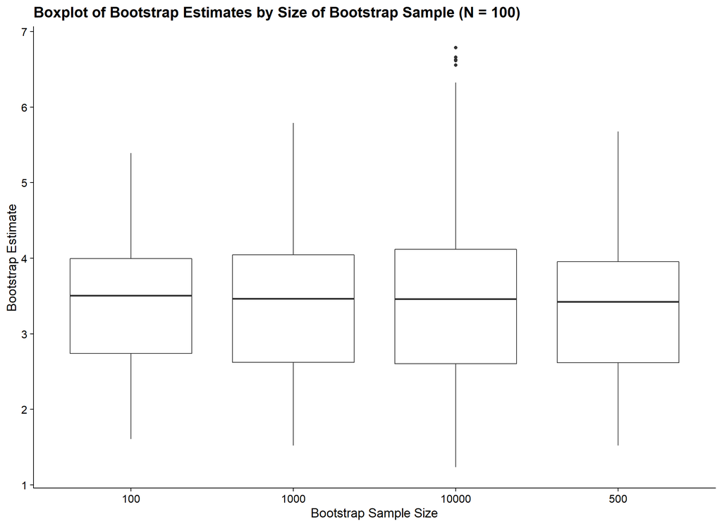

```r
ggplot(boot_cauchy_100_sd_tbl) +
  geom_boxplot(aes(x = vec_cast(btstrp_size, character()), y = btstrp_val)) +
  xlab("Bootstrap Sample Size") +
  ylab("Bootstrap Estimate") +
  ggtitle("Boxplot of Bootstrap Estimates by Size of Bootstrap Sample (N = 100)")
```

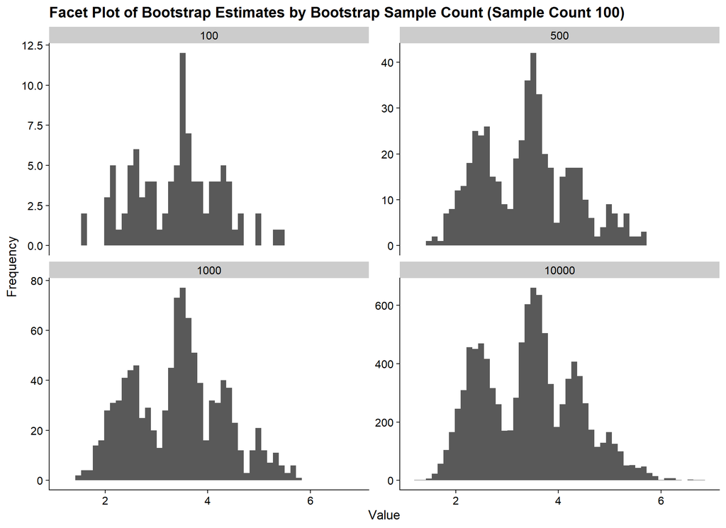

```r
ggplot(boot_cauchy_100_sd_tbl) +
  geom_histogram(aes(x = btstrp_val), bins = 50) +
  facet_wrap(vars(btstrp_size), scales = 'free_y') +
  xlab("Value") +
  ylab("Frequency") +
  ggtitle("Facet Plot of Bootstrap Estimates by Bootstrap Sample Count (Sample Count 100)")
```

### 1.5.2 Sample Size $N=1,000$

```r
boot_cauchy_1000_mean_tbl <- F_cauchy_tbl %>%
  head(1000) %>%
  pull(x) %>%
  construct_bootstrap_size_plots(mean)

boot_cauchy_1000_mean_tbl %>%
  group_by(btstrp_size) %>%
  summarise(summ = list(summary(btstrp_val))) %>%
  unnest_wider(summ)
```

```
## # A tibble: 4 x 7
##   btstrp_size  Min. `1st Qu.` Median  Mean `3rd Qu.`  Max.
##         <dbl> <dbl>     <dbl>  <dbl> <dbl>     <dbl> <dbl>
## 1         100 -1.13     0.152  0.914 0.840      1.54  3.54
## 2         500 -1.21     0.207  0.803 0.866      1.51  3.79
## 3        1000 -1.75     0.188  0.813 0.849      1.49  3.79
## 4       10000 -2.31     0.178  0.776 0.837      1.43  5.23
```

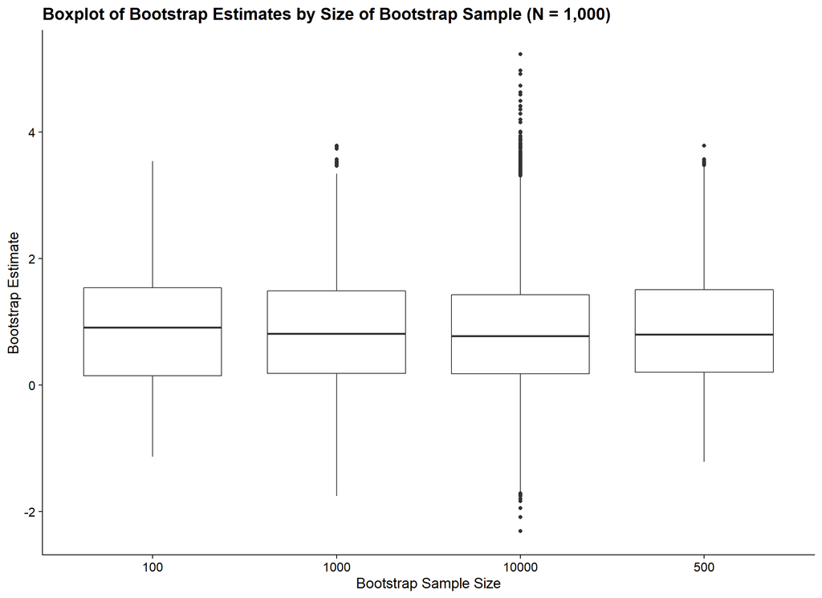

```r
ggplot(boot_cauchy_1000_mean_tbl) +
  geom_boxplot(aes(x = vec_cast(btstrp_size, character()), y = btstrp_val)) +
  xlab("Bootstrap Sample Size") +
  ylab("Bootstrap Estimate") +
  ggtitle("Boxplot of Bootstrap Estimates by Size of Bootstrap Sample (N = 1,000)")
```

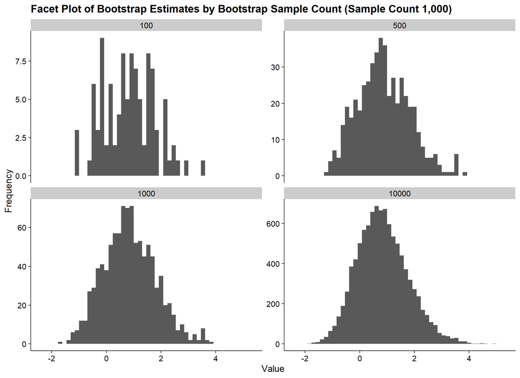

```r
ggplot(boot_cauchy_1000_mean_tbl) +
  geom_histogram(aes(x = btstrp_val), bins = 50) +
  facet_wrap(vars(btstrp_size), scales = 'free_y') +
  xlab("Value") +
  ylab("Frequency") +
  ggtitle("Facet Plot of Bootstrap Estimates by Bootstrap Sample Count (Sample Count 1,000)")
```

#### 1.5.2.1 Estimating the Variance

```r
boot_cauchy_1000_sd_tbl <- F_cauchy_tbl %>%
  head(1000) %>%
  pull(x) %>%
  construct_bootstrap_size_plots(sd)

boot_cauchy_1000_sd_tbl %>%
  group_by(btstrp_size) %>%
  summarise(summ = list(summary(btstrp_val))) %>%
  unnest_wider(summ)
```

```
## # A tibble: 4 x 7
##   btstrp_size  Min. `1st Qu.` Median  Mean `3rd Qu.`  Max.
##         <dbl> <dbl>     <dbl>  <dbl> <dbl>     <dbl> <dbl>
## 1         100 12.8       24.8   29.8  29.7      35.2  45.4
## 2         500 11.2       23.5   29.1  29.2      34.8  49.4
## 3        1000  9.48      24.2   29.7  29.5      34.9  51.5
## 4       10000  8.25      23.4   28.8  28.8      34.2  56.4
```

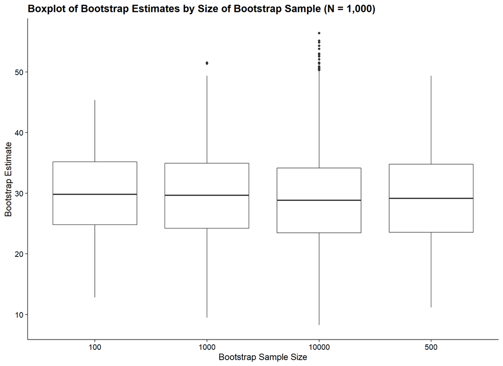

```r
ggplot(boot_cauchy_1000_sd_tbl) +
  geom_boxplot(aes(x = vec_cast(btstrp_size, character()), y = btstrp_val)) +
  xlab("Bootstrap Sample Size") +
  ylab("Bootstrap Estimate") +
  ggtitle("Boxplot of Bootstrap Estimates by Size of Bootstrap Sample (N = 1,000)")
```

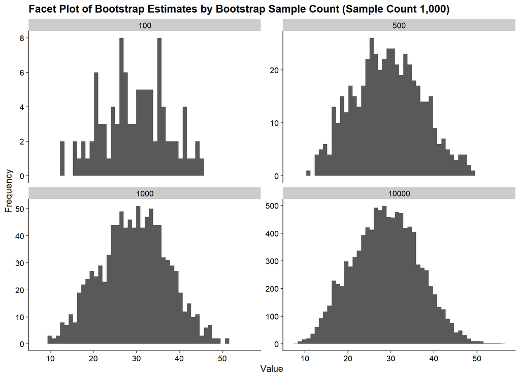

```r
ggplot(boot_cauchy_1000_sd_tbl) +
  geom_histogram(aes(x = btstrp_val), bins = 50) +
  facet_wrap(vars(btstrp_size), scales = 'free_y') +
  xlab("Value") +
  ylab("Frequency") +
  ggtitle("Facet Plot of Bootstrap Estimates by Bootstrap Sample Count (Sample Count 1,000)")
```

# 2 Bootstrapping Bivariate Data

So far we have focused on the use of the bootstrap for estimating the sample error in estimating population statistics from sample statistics, but the concepts and methods are applicable in general: we can use the bootstrap in a wide variety of applications.

To start the generalisation, we switch our attention to bivariate data and the bivariate normal in particular.

## 2.1 Bivariate Normal with Low Correlation, $\rho = 0.1$

We follow our previous approach, generating data from a distribution with known parameters and then try to recover the parameters from our samples.

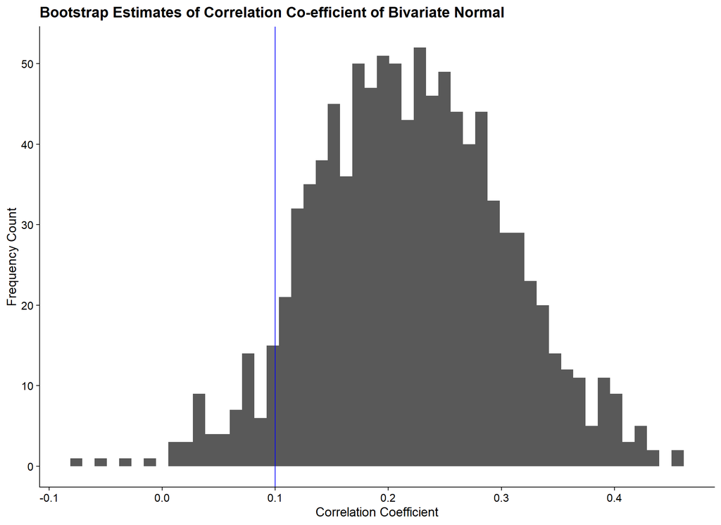

```r
rho   <- 0.1

Mu    <- c(0, 0)
Sigma <- matrix(c(1, rho, rho, 1), ncol = 2)



mvnorm_100_tbl <- MASS::mvrnorm(n = 100, mu = Mu, Sigma = Sigma) %>%
  set_colnames(c('x', 'y')) %>%
  as_tibble()

calc_cor <- ~ .x %>% analysis() %>% summarise(cor_val = cor(x, y)) %>% pull(cor_val)

mvnorm_100_boot_cor_tbl <- mvnorm_100_tbl %>%
  bootstraps(times = 1000) %>%
  mutate(cor_val = map_dbl(splits, calc_cor))


ggplot(mvnorm_100_boot_cor_tbl) +
  geom_histogram(aes(x = cor_val), bins = 50) +
  geom_vline(aes(xintercept = rho), colour = 'blue') +
  xlab("Correlation Coefficient") +
  ylab("Frequency Count") +
  ggtitle("Bootstrap Estimates of Correlation Co-efficient of Bivariate Normal")
```

We repeat this experiment but now with 1,000 data points in our sample.

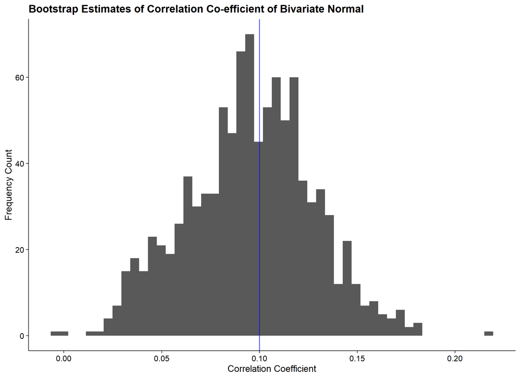

```r
mvnorm_1000_tbl <- MASS::mvrnorm(n = 1000, mu = Mu, Sigma = Sigma) %>%
  set_colnames(c('x', 'y')) %>%
  as_tibble()

calc_cor <- ~ .x %>% analysis() %>% summarise(cor_val = cor(x, y)) %>% pull(cor_val)

mvnorm_1000_boot_cor_tbl <- mvnorm_1000_tbl %>%
  bootstraps(times = 1000) %>%
  mutate(cor_val = map_dbl(splits, calc_cor))


ggplot(mvnorm_1000_boot_cor_tbl) +
  geom_histogram(aes(x = cor_val), bins = 50) +
  geom_vline(aes(xintercept = rho), colour = 'blue') +
  xlab("Correlation Coefficient") +
  ylab("Frequency Count") +
  ggtitle("Bootstrap Estimates of Correlation Co-efficient of Bivariate Normal")
```

Let’s compare the two bootstrap estimates.

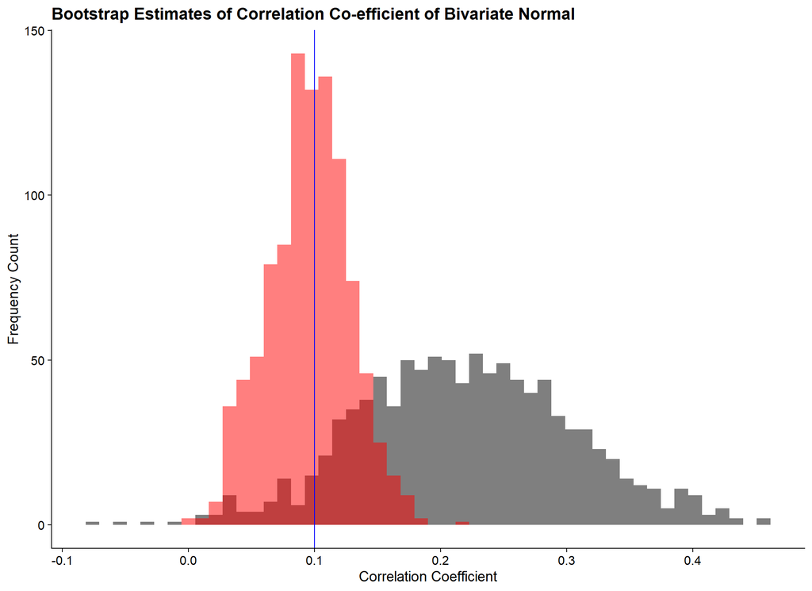

```r
ggplot() +
  geom_histogram(aes(x = cor_val), data = mvnorm_100_boot_cor_tbl, bins = 50,
                 fill = 'black', alpha = 0.5) +
  geom_histogram(aes(x = cor_val), data = mvnorm_1000_boot_cor_tbl, bins = 50,
                 fill = 'red', alpha = 0.5) +
  geom_vline(aes(xintercept = rho), colour = 'blue') +
  xlab("Correlation Coefficient") +
  ylab("Frequency Count") +
  ggtitle("Bootstrap Estimates of Correlation Co-efficient of Bivariate Normal")
```

## 2.2 Bivariate Normal with Medium Correlation, $\rho = 0.5$

We follow our previous approach, generating data from a distribution with known parameters and then try to recover the parameters from our samples.

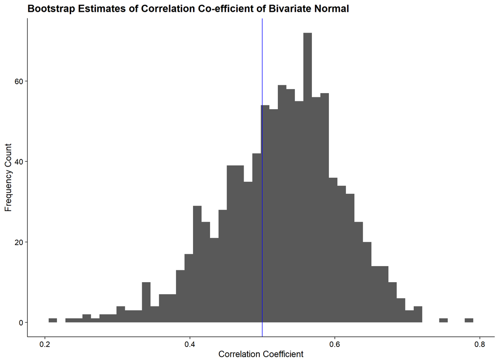

```r
rho   <- 0.5

Mu    <- c(0, 0)
Sigma <- matrix(c(1, rho, rho, 1), ncol = 2)


mvnorm_med_100_tbl <- MASS::mvrnorm(n = 100, mu = Mu, Sigma = Sigma) %>%
  set_colnames(c('x', 'y')) %>%
  as_tibble()

calc_cor <- ~ .x %>% analysis() %>% summarise(cor_val = cor(x, y)) %>% pull(cor_val)

mvnorm_med_100_boot_cor_tbl <- mvnorm_med_100_tbl %>%
  bootstraps(times = 1000) %>%
  mutate(cor_val = map_dbl(splits, calc_cor))


ggplot(mvnorm_med_100_boot_cor_tbl) +
  geom_histogram(aes(x = cor_val), bins = 50) +
  geom_vline(aes(xintercept = rho), colour = 'blue') +
  xlab("Correlation Coefficient") +
  ylab("Frequency Count") +
  ggtitle("Bootstrap Estimates of Correlation Co-efficient of Bivariate Normal")
```

We repeat this experiment but now with 1,000 data points in our sample.

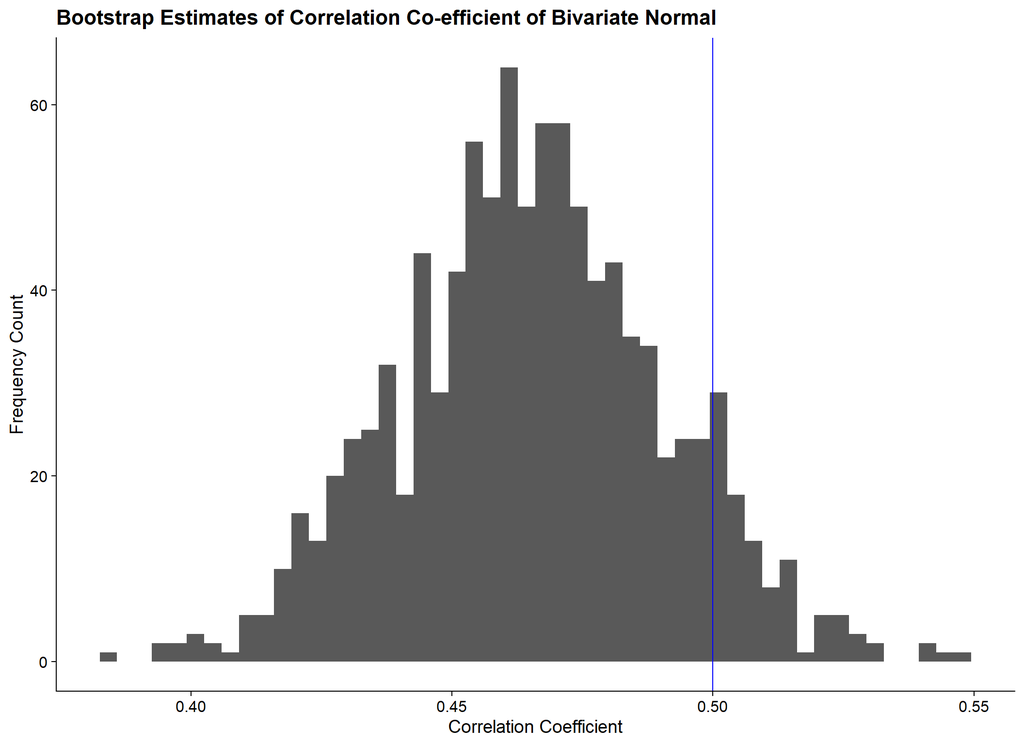

```r
mvnorm_med_1000_tbl <- MASS::mvrnorm(n = 1000, mu = Mu, Sigma = Sigma) %>%
  set_colnames(c('x', 'y')) %>%
  as_tibble()

calc_cor <- ~ .x %>% analysis() %>% summarise(cor_val = cor(x, y)) %>% pull(cor_val)

mvnorm_med_1000_boot_cor_tbl <- mvnorm_med_1000_tbl %>%
  bootstraps(times = 1000) %>%
  mutate(cor_val = map_dbl(splits, calc_cor))


ggplot(mvnorm_med_1000_boot_cor_tbl) +
  geom_histogram(aes(x = cor_val), bins = 50) +
  geom_vline(aes(xintercept = rho), colour = 'blue') +
  xlab("Correlation Coefficient") +
  ylab("Frequency Count") +
  ggtitle("Bootstrap Estimates of Correlation Co-efficient of Bivariate Normal")
```

Let’s compare the two bootstrap estimates.

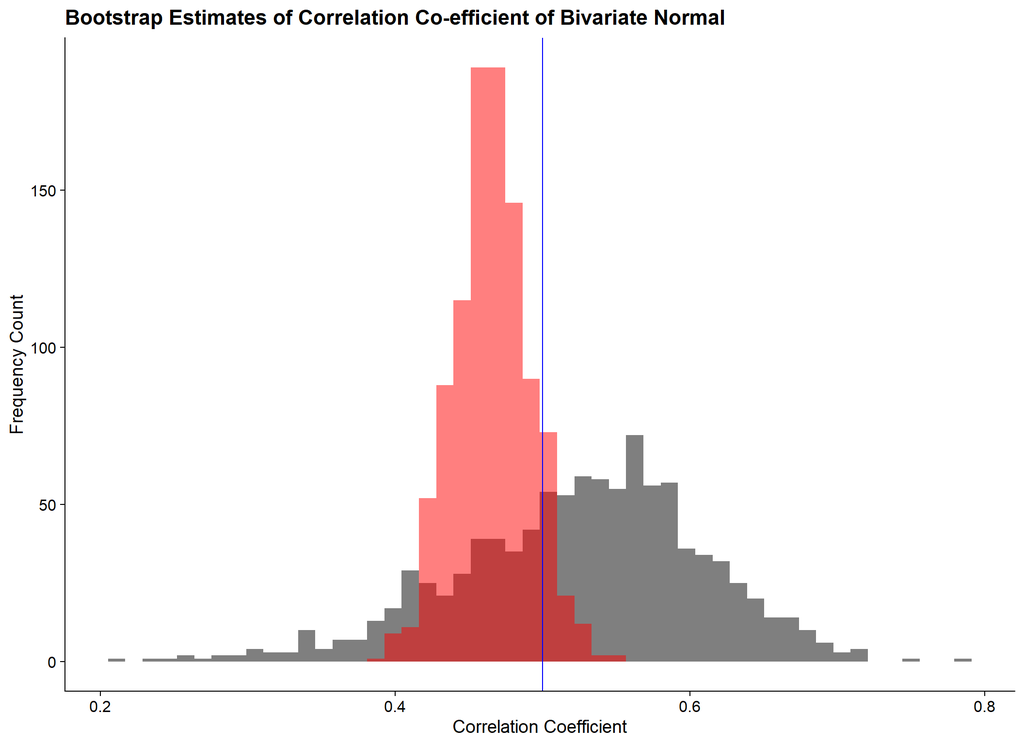

```r
ggplot() +
  geom_histogram(aes(x = cor_val), data = mvnorm_med_100_boot_cor_tbl,
                 bins = 50, fill = 'black', alpha = 0.5) +
  geom_histogram(aes(x = cor_val), data = mvnorm_med_1000_boot_cor_tbl,
                 bins = 50, fill = 'red', alpha = 0.5) +
  geom_vline(aes(xintercept = rho), colour = 'blue') +
  xlab("Correlation Coefficient") +
  ylab("Frequency Count") +
  ggtitle("Bootstrap Estimates of Correlation Co-efficient of Bivariate Normal")
```

## 2.3 Bivariate Normal with High Correlation, $\rho = 0.8$

We follow our previous approach, generating data from a distribution with known parameters and then try to recover the parameters from our samples.

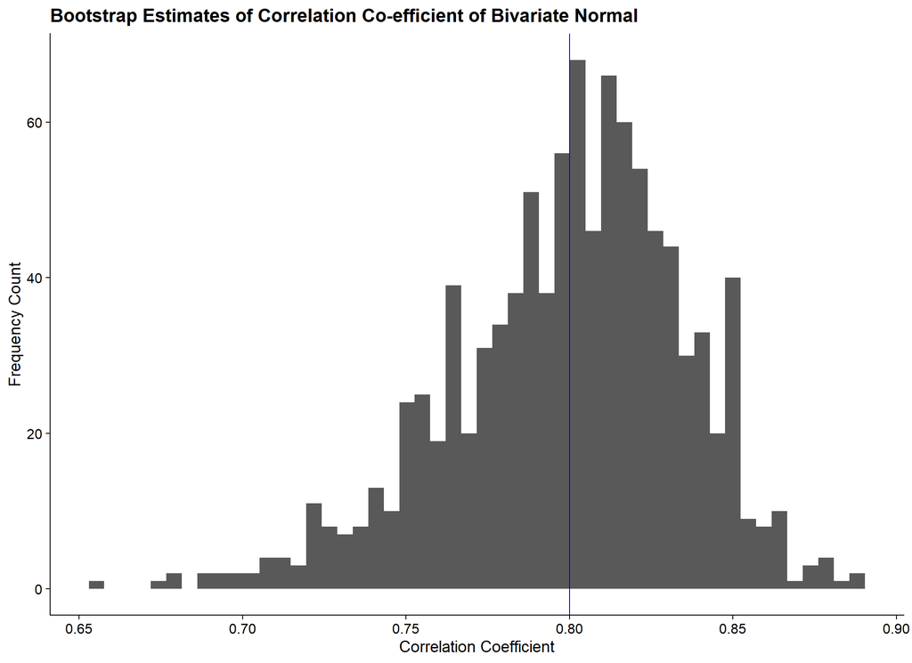

```r
rho   <- 0.8

Mu    <- c(0, 0)
Sigma <- matrix(c(1, rho, rho, 1), ncol = 2)


mvnorm_high_100_tbl <- MASS::mvrnorm(n = 100, mu = Mu, Sigma = Sigma) %>%
  set_colnames(c('x', 'y')) %>%
  as_tibble()

calc_cor <- ~ .x %>% analysis() %>% summarise(cor_val = cor(x, y)) %>% pull(cor_val)

mvnorm_high_100_boot_cor_tbl <- mvnorm_high_100_tbl %>%
  bootstraps(times = 1000) %>%
  mutate(cor_val = map_dbl(splits, calc_cor))


ggplot(mvnorm_high_100_boot_cor_tbl) +
  geom_histogram(aes(x = cor_val), bins = 50) +
  geom_vline(aes(xintercept = rho), colour = 'blue') +
  xlab("Correlation Coefficient") +
  ylab("Frequency Count") +
  ggtitle("Bootstrap Estimates of Correlation Co-efficient of Bivariate Normal")
```

We repeat this experiment but now with 1,000 data points in our sample.

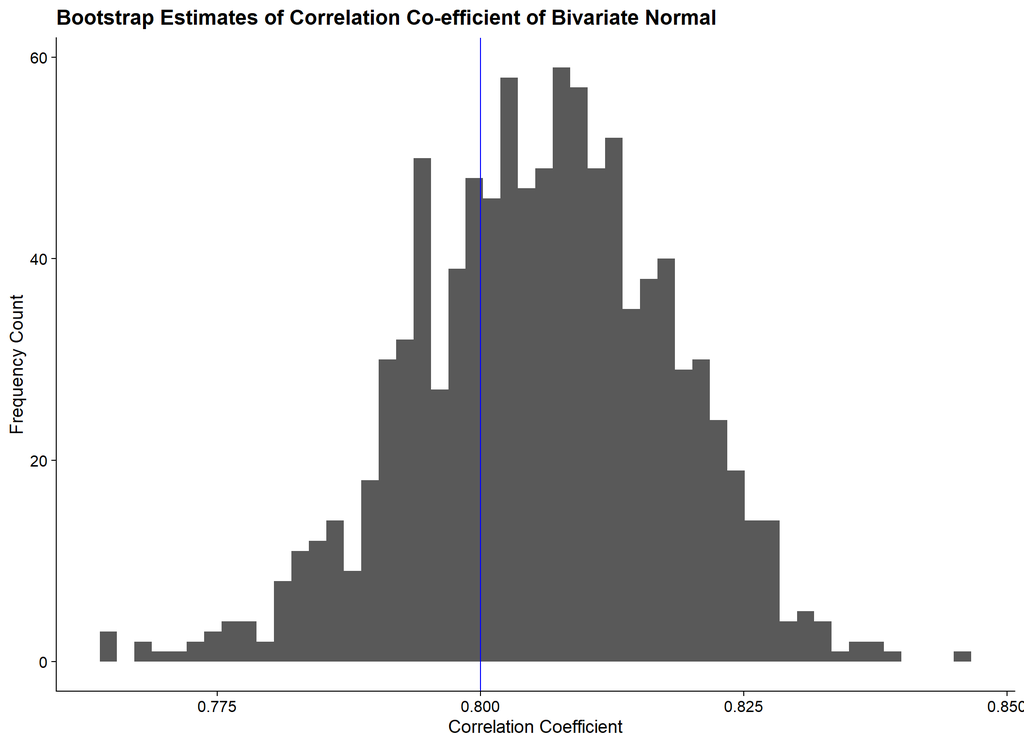

```r
mvnorm_high_1000_tbl <- MASS::mvrnorm(n = 1000, mu = Mu, Sigma = Sigma) %>%
  set_colnames(c('x', 'y')) %>%
  as_tibble()

calc_cor <- ~ .x %>% analysis() %>% summarise(cor_val = cor(x, y)) %>% pull(cor_val)

mvnorm_high_1000_boot_cor_tbl <- mvnorm_high_1000_tbl %>%
  bootstraps(times = 1000) %>%
  mutate(cor_val = map_dbl(splits, calc_cor))


ggplot(mvnorm_high_1000_boot_cor_tbl) +
  geom_histogram(aes(x = cor_val), bins = 50) +
  geom_vline(aes(xintercept = rho), colour = 'blue') +
  xlab("Correlation Coefficient") +
  ylab("Frequency Count") +
  ggtitle("Bootstrap Estimates of Correlation Co-efficient of Bivariate Normal")
```

Let’s compare the two bootstrap estimates.

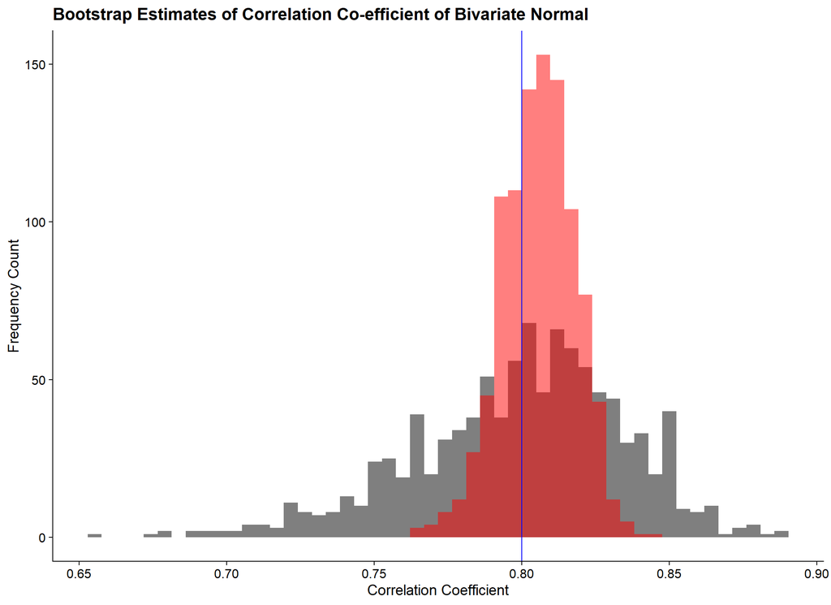

```r
ggplot() +
  geom_histogram(aes(x = cor_val), data = mvnorm_high_100_boot_cor_tbl,
                 bins = 50, fill = 'black', alpha = 0.5) +
  geom_histogram(aes(x = cor_val), data = mvnorm_high_1000_boot_cor_tbl,
                 bins = 50, fill = 'red', alpha = 0.5) +
  geom_vline(aes(xintercept = rho), colour = 'blue') +
  xlab("Correlation Coefficient") +
  ylab("Frequency Count") +
  ggtitle("Bootstrap Estimates of Correlation Co-efficient of Bivariate Normal")
```